# Bogenschnitt mittels orientierter Wegbeschreibung

Oliver Fritz

## Aufgabenstellung

```r
# Hier die Parameter des Bogenschnitts einfügen/anpassen:

P1 <- c(176678, 9783668)
P2 <- c(178956, 9783624)
s1 <- 1114
s2 <- 1224

orientation <- "cartesian" # Optionen: "geodetic" | "cartesian"
position <- "left" # Optionen: "left" | "right"
```

Gegeben seien die *kartesischen* Koordinaten der Punkte $P_1=\binom{176678}{9783668}$ und $P_2=\binom{178956}{9783624}$ sowie die Strecken $s_1=1114$ und $s_2=1224$. Man bestimme die Koordinaten für den Punkt $P_3$, welcher links von $\overline{P_1P_2}$ liegt!

## Benötigte Erweiterungen

```r
source("MatheGIS.R")
```

## Graphische Darstellung

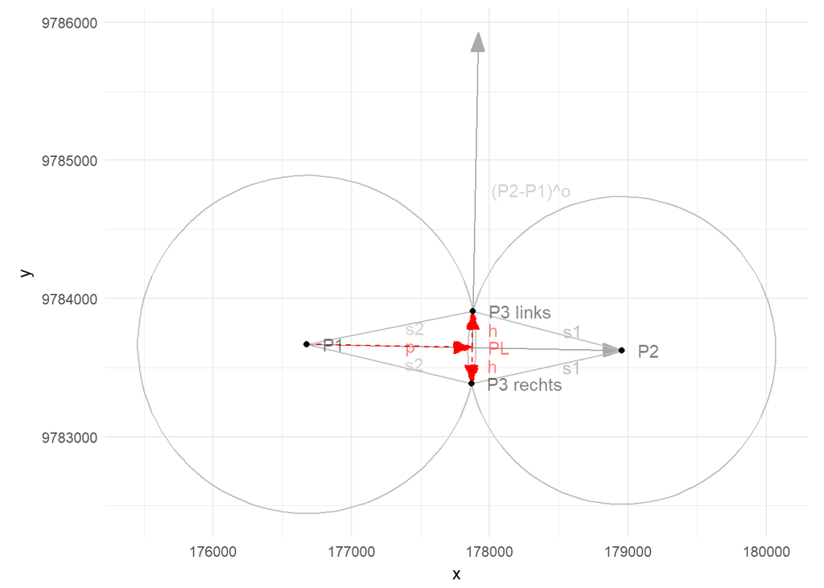

```r
plot_bogenschnitt(P1=P1, P2=P2, s1=s1, s2=s2, orientation=orientation)
```

## Lösung

### Berechnung

Die Lösung des Bogenschnitts mittels orientierter Wegbeschreibung hat folgende Form:
$$P_3=P_1+\frac{p}{s_3}(P_2-P_1)\pm\frac{h}{s_3}(P_2-P_1)^{\circ}$$

### Beschreibung

Ausgehend von $P_1$ bewegt man sich auf der mit dem Streckenparameter $t=\frac{p}{s_3}$ multiplizierten Strecke $\overline{P_1P_2}$. Ist $t<0$, bewegt man sich dabei von $P_2$ fort, ansonsten aber auf $P_2$ zu. Ist $0<t<1$, so endet der Weg zwischen $P_1$ und $P_2$. Bei $t>1$, d.h. $p>s_3$ geht der Weg über $P_2$ hinaus. Die Strecke $s_3$ ist die dem Punkt $P_3$ gegenüberliegende Seite in dem aus $P_1$, $P_2$ und $P_3$ gebildeten Dreieck , also die Strecke $\overline{P_1P_2}$. Nach Zurücklegen dieses ersten Wegabschnitts erreicht man den Lotfußpunkt $P_L$.

Im zweiten Schritt bewegt man sich weiter auf dem mit dem Streckenparameter $u=\frac{h}{s_3}$ multiplizierten orientierten Normalenvektor $(P_2-P_1)^{\circ}$. Der orientierte Normalenvektor steht im Drehsin des Koordinatensystems orthogonal zum Richtungsvektor (Drehsinn geodätisch: mit dem Uhrzeigersinn, kartesisch: entgegengesetzt). Das Plusminus-Vorzeichen lässt dabei ein Abbiegen sowohl nach links oder rechts zu. Die Position des Punktes $P_3$ links oder rechts der Strecke $\overline{P_1P_2}$ erschließt sich nicht aus den gegebenen beiden Punkten und Streckenlängen.

### Bestimmung von ${s_3}^2$

Zunächst berechnen wir das Quadrat der Strecke $s_3$ aus den Koordinaten der Punkte $P_1$ und $P_2$:

```r
s3quadrat <- streckenquadrat(P1, P2)
```

$$\begin{equation}
\begin{split}
{s_3}^2&=(x_2-x_1)^2+(y_2-y_1)^2\\\\
&=(178956-176678)^2+(9783624-9783668)^2\\\\
&\approx5191220
\end{split}
\end{equation}$$

### Bestimmung des ersten Streckenparameters $t$

Der Streckenparameter $t=\frac{p}{s_3}$ kann als Funktion von $s_1$, $s_2$ und ${s_3}^2$ ermittelt werden.

```r
t <- param_ps3(s1, s2, s3quadrat)
```

$$\begin{equation}
\begin{split}
\frac{p}{s_3}&=\frac{1}{2}(1+\frac{{s_2}^2}{{s_3}^2}-\frac{{s_1}^2}{{s_3}^2})\\\\
&\approx\frac{1}{2}(1+\frac{1498176}{5191220}-\frac{1240996}{5191220})\\\\
&\approx0.5248
\end{split}
\end{equation}$$

### Bestimmung des zweiten Streckenparameters $u$

Der zweite Streckenparameter $u=\frac{h}{s_3}$ kann als Funktion von $s_2$, ${s_3}^2$ und dem ersten Streckenparameter $t=\frac{p}{s_3}$ ermittelt werden.

```r
u <- param_hs3(s2, s3quadrat, t)
```

$$\begin{equation}
\begin{split}
\frac{h}{s_3}&=\sqrt{\frac{{s_2}^2}{{s_3}^2}-(\frac{p}{s_3})^2}\\\\
&\approx\sqrt{\frac{1498176}{5191220}-0.2754}\\\\
&\approx0.115
\end{split}
\end{equation}$$

### Bestimmung der Koordinaten des Punktes $P_3$

Nach Berechnung der Parameter können nun mittels der Formel für den Bogenschnitt die Koordinaten des Punktes $P_3$ bestimmt werden.

```r
P3 <- bogenschnitt_P3(P1=P1, P2=P2, s1=s1, s2=s2, orientation=orientation, position=position)
```

Da $P_3$ links von $\overline{P_1P_2}$ liegt und das Koordinatensystem kartesisch ist, erhält der Streckenparameter $u=\frac{h}{s_3}$ ein positives Vorzeichen (geodätischer Drehsinn: Uhrzeigersinn, kartesischer Drehsinn: gegen die Uhr).

$$\begin{equation}
\begin{split}
P_3&=P_1+\frac{p}{s_3}(P_2-P_1)+\frac{h}{s_3}(P_2-P_1)^{\circ}\\\\
&\approx\binom{176678}{9783668}+0.5248\binom{178956-176678}{9783624-9783668}+0.115\binom{-(9783624-9783668)}{178956-176678}\\\\
&\approx\binom{177878.5}{9783907}
\end{split}
\end{equation}$$

Der Punkt $P_3$ hat die x-Koordinate 177878.5 und die y-Koordinate 9783907.